# Say Their Names, Remember Their Lives

Group 15 - Asad Sheikh, Vivian Sun, William Zeng, Anna Niu

5/9/2021

# Introduction

Before we examine the topic of police brutality in America, we must pay tribute to those who have lost their lives to police brutality. They are not just statistics, but rather individuals who fell victim to a system riddled with injustice. Even though their deaths were a moment in time, the scars inflicted upon their communities, their families, their livelihoods, will forever remain ingrained in our history.

We must **say their names**.

Our group examined the [**Fatal Encounters Dataset**](https://fatalencounters.org/), which works to create an impartial, comprehensive, and searchable national database of people killed during interactions with the police. There are **29993 rows** and **30 columns** in this dataset. Each row corresponds to a fatal encounter. There are some location-based variables like the **Location of injury** and the **Location of death** (the state, zip code, county, and full address, latitude and longitude). There is also a time-based variable for the **Date** of the incident. Some categorical variables include:

- Age
- Gender (Male,Female)
- Race (European-American/White, African-American/Black, Hispanic/Latino, Race unspecified, Native American/Alaskan, Asian/Pacific Islander, Middle Eastern)
- Highest Level of Force
- Intended use of force
- Foreknowledge of mental illness (Yes, No, Unknown, Drug or Alcohol Use)

It also shows imputation probability, whether a race was imputed or not and the probability of accuracy in the imputed races. For a subset of the data (~11,000 entries from 2014 to mid 2020), they also track: + Armed/Unarmed + Alleged weapon +Aggressive physical movement + Fleeing/Not fleeing.

Many of the remaining columns are not useful for visualisation since they show descriptions, names, links to outside information, or IDs.

Our group sought to understand this dataset in the current social climate - are there trends or any insights relating to evidence of systemic racism through incidents of police brutality? We divided our project into examining the following three research questions based on the information available in our dataset.

- 1. **Are there any geographic trends relating to fatal encounters?**
- 2. **Are there any time-based trends that highlight seemingly increasing prevalence of police brutality?**
- 3. **Is there evidence of a systemic bias against particular racial groups?**

# Question 1: Examining Geographic Trends Relating to Police Brutality

We first wanted to see if the rate of fatal encounters was associated with the state. Are there particular states in which police brutality incidents occur at a higher rate?

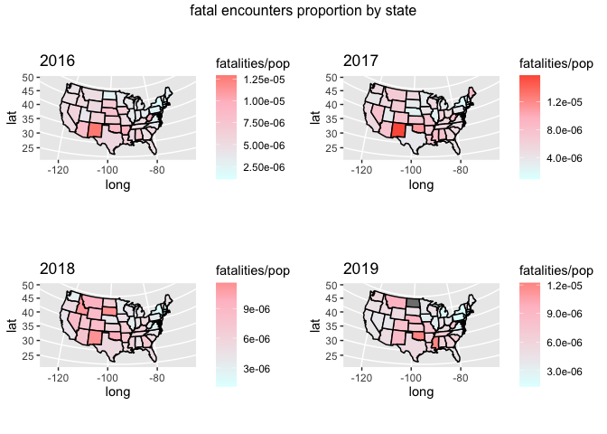

# Question 2: Understanding Police Brutality Trends Over Time

While we did not find any geographic trends over time relating to police brutality incidents, we decided to continue to explore time-based trends but on a larger scale. Rather than looking at specific states, we looked at the United States as a whole and first examined the number of incidents per month with a further lens on the highest level of force used by the police officer.

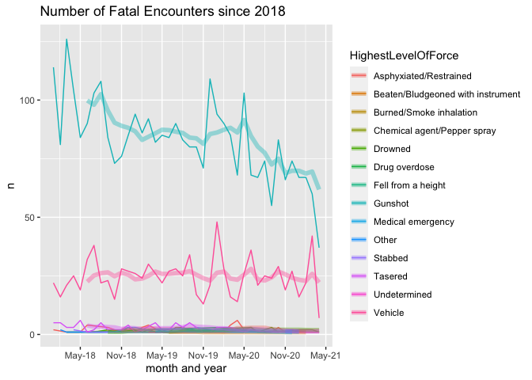

From this graph, it is interesting to see the overall decrease in number of fatal encounters. The most common level of force is a gunshot, followed by vehicle. The overall trend lines show that in general, the number of killings in gunshots is decreasing while the other levels of force remain the same as many are close to 0. Given the current social climate, it is interesting to see that overall, fatal encounters are decreasing, but social media can seem saturated with posts about fatal encounters.

As we saw that the number of fatal encounters appears to be decreasing, we wondered if that trend is the same across racial lines. Our next time-based trend sought to understand if the proportion of police brutality victims is the same for all racial lines. Or, is a specific group being killed at a higher rate than in the past?

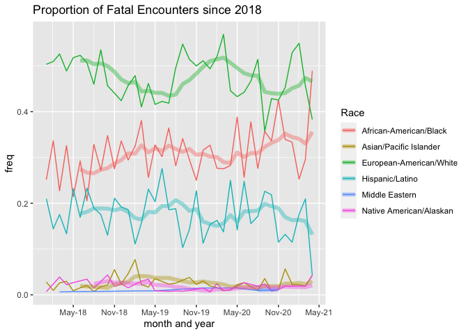

# Question 3: Uncovering any Disproportionate Impacts of Police Brutality

As we answered the last question, we saw that there was an increase in rates of fatal encounters for African-American/Black in the early months of 2021. How does this compare to historical trends?

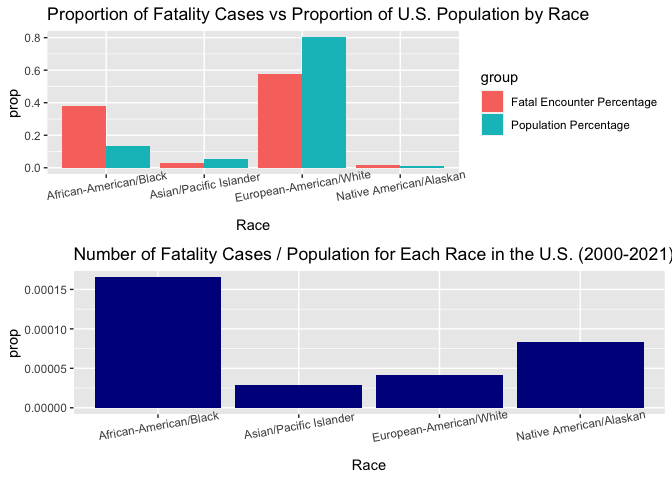

After comparing population proportions and fatal encounter proportion, we then examined the text data that contained a brief description of the event that generally came from media sources and police records. Because police officers are usually the only ones who contribute to these descriptions, we are interested in this other aspect of systemic measures that influence perception of fatal encounters as the media is how everyday citizens find out about such fatal encounters.

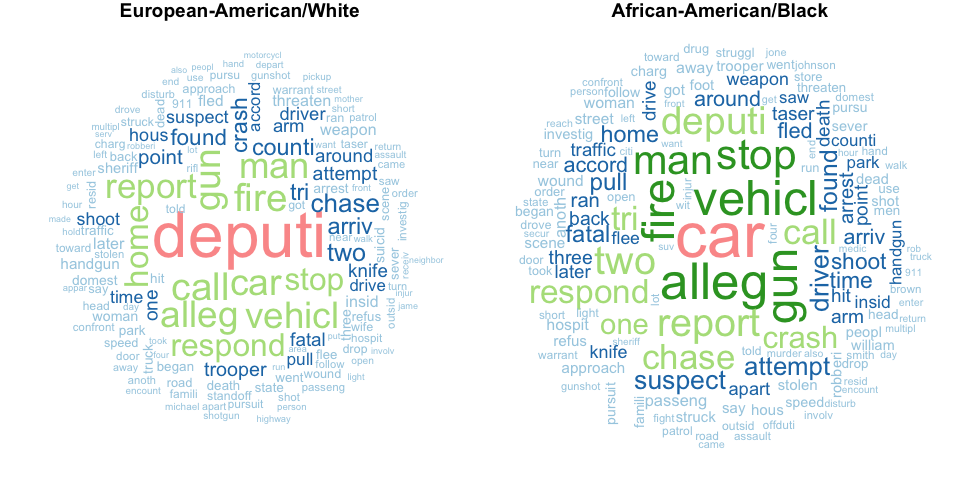

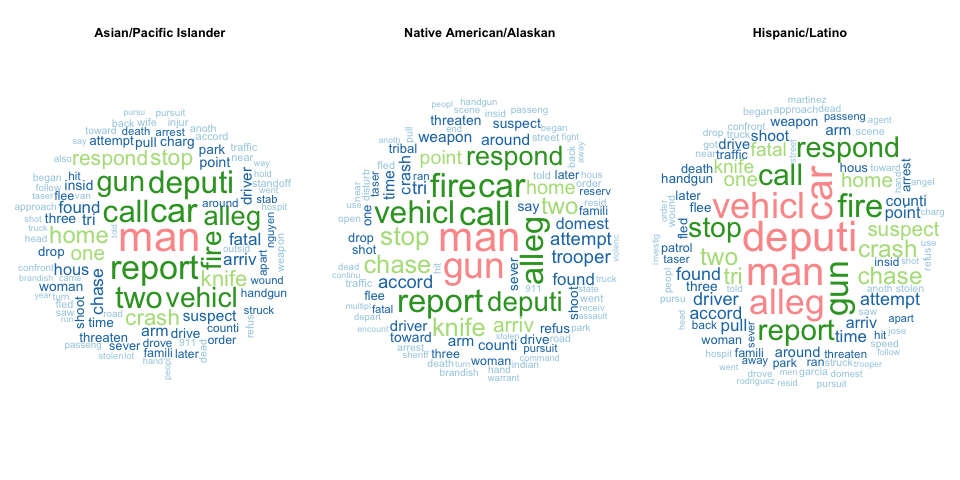

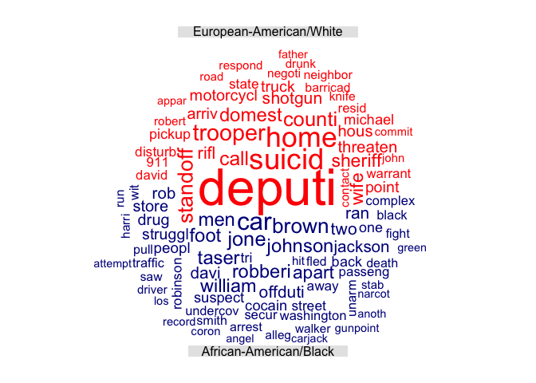

From this word cloud, some words such as suicide, deputies, home, and wife are more common for the European-American/White group, while words such as taser, struggle, and robberies are more common for the African-American/Black group. Overall, it seems that more of the European-American/White cases are deaths inside the home, whether it’s domestic violence or suicide. More of the African-American/Black cases seem to be related to robberies and drug cases. The contrast between words such as threaten and standoff for the European-American/White group, which imply confrontation, and words such as ran, away, and car for the African-American/Black seems to indicate different actions taken by the victims. It’s also apparent that there are more frequent mentions of weapons when describing European-American/White cases. The differences described support the thought that the situations revolving around fatal encounters differ between these two racial groups.

After examining word content of the description, we then explored the sentiments of the descriptions for each fatal encounter.

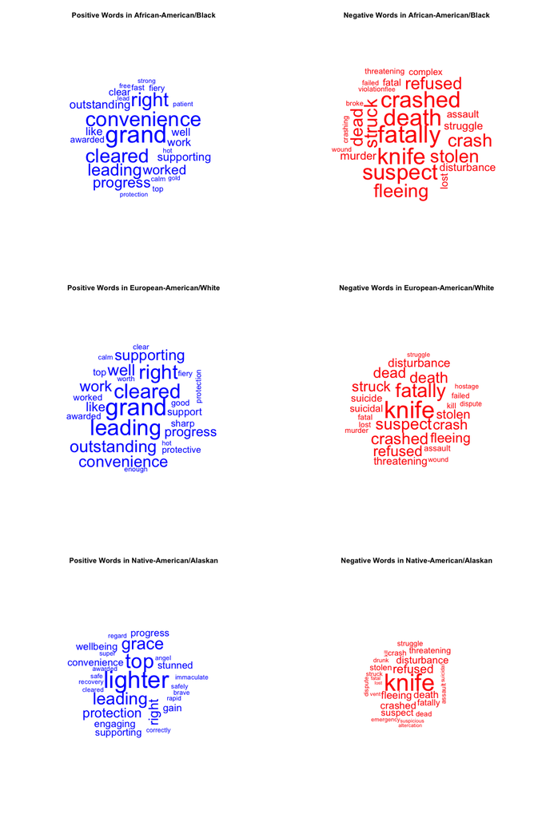

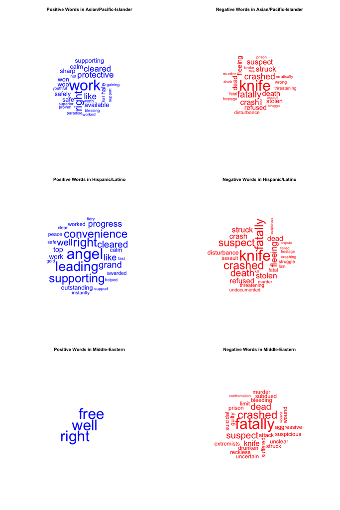

In addition to the brief description, police officers also report the alleged weapon of the suspect and the intended use of force of the police officer.

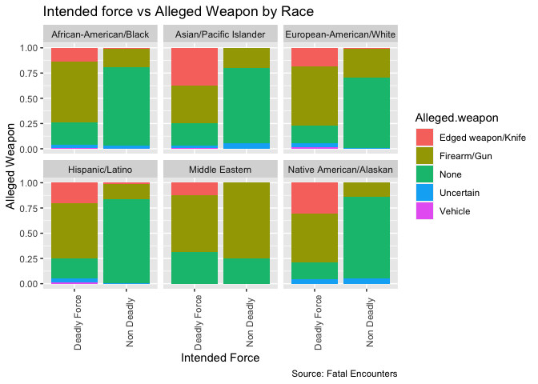

We see here that most intended uses of deadly force involve weapons, specifically knives, guns, and handguns. Most non deadly force involves no weapons, with only ~20% involving handguns by race. The Middle Eastern bar plot seems to have an exception, but it had small sample size. We can see that a slightly larger percentage of fatal encounters where the police officer was intending on using nonlethal force for European-American/White people who were armed with a firearm in comparison to all other races. Although the difference is small, it could possibly indicate that police officers are less likely to use lethal force against armed European-American/White people.

The race of an individual in this dataset and the intended use of force seem to be dependent. We ran a chi-squared test for independence between Race and deadly force. Race is the race of the individual, which is either European-American/White, African-American/Black, Hispanic/Latino, Native American/Alaskan, Asian/Pacific Islander, or Middle Eastern. Deadly force is whether the officer intended to use deadly force on the individual. We see that it is significantly different across races. We obtained a p-value of 1.119e-7, which is nearly zero. This indicates that an alpha of 0.05, we can reject the null hypothesis that intended force and race are independent.

# Conclusion & Discussion

Systemic racism is especially ingrained in our police system today. We are able to see simply from the data that there is a discrepancy in the way members of specific racial groups are targeted and killed by police officers. We must never forget those who died and must create change in our society to bring justice to those who were so wrongly taken from us.